# Synoptic Arctic Survey 2021 - metatranscriptomics and metabarcoding

Author

george.westmeijer@umu.se

Published

April 28, 2026

# Load libraries

**Expand code**

```r
cite_packages(output = "table", pkgs = "Session", out.dir = getwd())
```

```
    Package Version   Citation
1      base   4.5.3      @base
2 patchwork   1.3.2 @patchwork
3 tidyverse   2.0.0 @tidyverse
```

**Expand code**

```r
cols.layer <- c(
  "10m" = "#78B7C5",
  "chlMax" = "#046C9A"
)
```

# Read input files RNA

The raw data was procesesd using nf-core/metatdenovo (v1.0.1): https://nf-co.re/metatdenovo/1.0.1/ using Prokka as orf caller, GTDB release 220 for taxonomic annotation, and EggNOG mapper for functional annotation.

**Expand code**

```r
tax <- read_tsv('data/metatdenovo/gtdb_ncbi_merged.tsv.gz', col_types = 'cccccccc')
```

**Expand code**

```r
tpm <- read_tsv("data/metatdenovo/user_assembly.prokka.counts.tsv.gz", show_col_types = F) %>%
  mutate(sample = gsub("R", ".", sample)) %>%
  mutate(sample = factor(sample, levels = c(
    "S1.1", "S1.2", "S2.1", "S2.2", "S3.1", "S3.2", "S4.1", "S4.2", "S5.1", "S6.1",
    "S5.2", "S6.2", "S7.1", "S7.2", "S8.1", "S8.2", "S9.1", "S9.2", "S10.1", "S10.2"
  ))) %>%
  select(-start, -end,- strand, -length, -chr)

meta <- read_tsv("data/sample_key.tsv", show_col_types = FALSE) %>%
  mutate(station = as.character(station)) %>%
  mutate(sample = gsub("R", ".", sample)) %>%
  mutate(sample = factor(sample, levels = c(
    "S1.1", "S1.2", "S2.1", "S2.2", "S3.1", "S3.2", "S4.1", "S4.2", "S5.1", "S6.1",
    "S5.2", "S6.2", "S7.1", "S7.2", "S8.1", "S8.2", "S9.1", "S9.2", "S10.1", "S10.2"
  ))) %>%
  mutate(layer = factor(layer, levels = c("10m", "chlMax")))
```

In total, there are 20 metatranscriptomes from five stations. At every station, samples were taken in duplicates from 10 m depth and from chl. max. On average, each sample has 81.2 million reads (sd 8.7, n = 20). Off all the transcripts, 53.0 % was functionally annotated (Eggnog mapper), 36.5 % was functionally annotated including a KO reference, 51.7 % of the transcripts was annotated on phylum level, 48.0 % on order level, 43.5 % on genus level, and 32.7 % on species level.

63.6 % of the transcript were functionally annotated with Kofam scan. A summary of the bioinformatic pipeline will soon be added to this introduction.

**Expand code**

```r
kofam <- read_tsv("data/metatdenovo/user_assembly.prokka.kofamscan-uniq.tsv.gz", show_col_types = F) %>%
  select(-thrshld, -score)
```

**Expand code**

```r
emapper <- read_tsv("data/metatdenovo/user_assembly.prokka.emapper.tsv.gz", show_col_types = F) %>%
  select(orf, cog = cog_category)
```

# Data exploration

## Percentage of annotated transcripts

**Expand code**

```r
i <- c("domain","phylum","class","order","family","genus")

for (level in i) {
  ## The (!!as.name(level)) converts the variable level to e.g. 'genus'
  d <- tpm %>% left_join(tax, by = "orf") %>% filter(!is.na((!!as.name(level))))
  format(nrow(d) / nrow(tpm) * 100, digits = 3) %>% paste(stringr::str_to_title(level), ": ", ., " %", sep = "") %>% print()
}
```

```
[1] "Domain: 55.4 %"
[1] "Phylum: 51.7 %"
[1] "Class: 50.1 %"
[1] "Order: 48 %"
[1] "Family: 47 %"
[1] "Genus: 43.5 %"
```

**Expand code**

```r
i <- c("domain","phylum","class","order","family","genus")

for (level in i) {
  ## The (!!as.name(level)) converts the variable level to e.g. 'genus'
  d <- tpm %>% left_join(tax, by = "orf") %>% inner_join(kofam, by = "orf") %>% filter(!is.na((!!as.name(level))))
  format(nrow(d) / nrow(tpm) * 100, digits = 3) %>% paste(stringr::str_to_title(level), ": ", ., " %", sep = "") %>% print()
}
```

```
[1] "Domain: 46.7 %"
[1] "Phylum: 43.2 %"
[1] "Class: 41.8 %"
[1] "Order: 40.2 %"
[1] "Family: 39.2 %"
[1] "Genus: 36 %"
```

## Community composition on domain level

**Expand code**

```r
tpm %>%
  left_join(tax, by = "orf") %>%
  replace_na(list("domain" = "Unknown")) %>%
  group_by(domain) %>% summarise(tpm = sum(tpm) / 20, .groups = "drop") %>%
  arrange(desc(tpm))
```

Table 1

```
# A tibble: 5 × 2
  domain        tpm
  <chr>       <dbl>
1 Unknown   407152.
2 Bacteria  377129.
3 Eukaryota 101564.
4 Archaea    94688.
5 Viruses    19467.
```

Figure 1 depicts the ratio between bacteria and archaea for both depth layers. Note how the abundance of archaea is slightly higher in most of the deeper samples (chlorophyll max depth).

**Expand code**

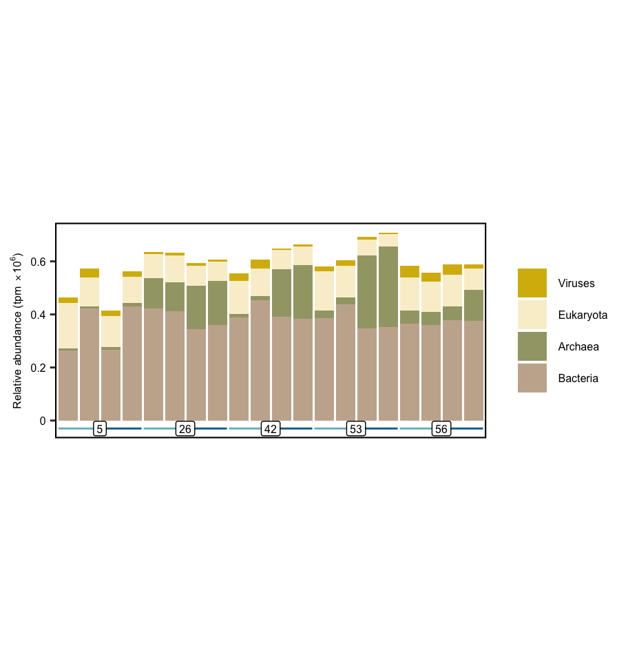

Figure 1: Community overview on domain level, removing transcripts without a taxonomic annotation.

```r
tpm %>%
  inner_join(tax, by = "orf") %>%
  inner_join(meta, by = "sample") %>%
  group_by(sample, domain) %>% summarise(tpm = sum(tpm), .groups = "drop") %>%
  mutate(domain = factor(domain, levels = c("Viruses", "Eukaryota", "Archaea", "Bacteria"))) %>%
  ggplot(aes(
    x = sample,
    y = tpm,
    fill = domain
  )) +
  geom_col() + theme_tidy() +
  scale_y_continuous(breaks = c(0, 2e5, 4e5, 6e5), labels = c(0, 0.2, 0.4, 0.6)) +
  labs(y = expression('Relative abundance (tpm '%*% '10'^'6'*')')) +
  scale_fill_manual(
    values = c("Bacteria" = "#C7B19C", "Archaea" = "#A2A475", "Viruses" = "#D8B70A", "Eukaryota" = "#FAEFD1")
    ) +
  theme(
    aspect.ratio = 0.5,
    legend.title = element_blank(),
    axis.title.x = element_blank(),
    axis.ticks.x = element_blank(),
    axis.text.x = element_blank()
  ) +
  annotate("segment", x =  0.55, xend =  2.45, y = -30000, yend = -30000, color = "#78B7C5") +
  annotate("segment", x =  2.55, xend =  4.45, y = -30000, yend = -30000, color = "#046C9A") +
  annotate("segment", x =  4.55, xend =  6.45, y = -30000, yend = -30000, color = "#78B7C5") +
  annotate("segment", x =  6.55, xend =  8.45, y = -30000, yend = -30000, color = "#046C9A") +
  annotate("segment", x =  8.55, xend = 10.45, y = -30000, yend = -30000, color = "#78B7C5") +
  annotate("segment", x = 10.55, xend = 12.45, y = -30000, yend = -30000, color = "#046C9A") +
  annotate("segment", x = 12.55, xend = 14.45, y = -30000, yend = -30000, color = "#78B7C5") +
  annotate("segment", x = 14.55, xend = 16.45, y = -30000, yend = -30000, color = "#046C9A") +
  annotate("segment", x = 16.55, xend = 18.45, y = -30000, yend = -30000, color = "#78B7C5") +
  annotate("segment", x = 18.55, xend = 20.45, y = -30000, yend = -30000, color = "#046C9A") +
  annotate("label", x = 2.5, y = -30000, label = "5", label.size = 0, size = 6/.pt) +
  annotate("label", x = 6.5, y = -30000, label = "26", label.size = 0, size = 6/.pt) +
  annotate("label", x =10.5, y = -30000, label = "42", label.size = 0, size = 6/.pt) +
  annotate("label", x =14.5, y = -30000, label = "53", label.size = 0, size = 6/.pt) +
  annotate("label", x =18.5, y = -30000, label = "56", label.size = 0, size = 6/.pt)
```